# Processing and visualising the NOAA Dataset of Significant Earthquakes

maianhdang

September 3, 2017

## Package Info

This is `noaa.visualise` package working with the NOAA Significant Earthquakes dataset to support the process of visualising and gaining information.

The packages includes the below groups:

| Group | Functions |
| --- | --- |
| Cleaning the raw data | eq_clean_data(), eq_location_clean(), eq_country_filter() |
| Visualisation tools | geom_timeline(), geom_timeline_lable(), stat_timeline(), theme_timeline() |
| Mapping tools | eq_map(), eq_create_label() |

## Included dataset

The [NOAA Significant Earhquake Dataset](https://www.ngdc.noaa.gov/nndc/struts/form?t=101650&s=1&d=1) contains the information of 5,933 earthquakes over the period of 4,000 years. **Cite:** National Geophysical Data Center / World Data Service (NGDC/WDS): Significant Earthquake Database. National Geophysical Data Center, NOAA. doi:10.7289/V5TD9V7K

It is also included in this package, and could be called by:

```r
raw_data <- data("raw_data")
```

Or, if the user have the earthquake data saved in the working directory as `"earthquakes.tsv.gz"`, it could be used in the following way:

`raw_data <- readr::read_delim("earthquakes.tsv.gz", delim = "\t")`

## Visualization Tools

#### geom_timeline()

A new geom for `ggplot2` called `geom_timeline()` would plot a timeline of earthquakes, ranging from `xmin` to `xmax` as the beginning and ending date points.

- `x aesthetic` is a date of earthquakes (`date` variable is created through `eq_clean_data()`.
- `y aesthetic` is a factor indicating some stratification in which case multiple time lines will be plotted for each level of the factor (e.g. `y = COUNTRY`).
- Optional aesthetic, `color`, `size`, `alpha` could be set to show additional information (e.g. `DEATHS`, Number of Death in each earthquakes; `EQ_PRIMARY`, Magnitude in Richter Scale)

For example:

```r
data("raw_data") ## obtain the included dataset
data <- noaa.visualise::eq_clean_data(raw_data)
```

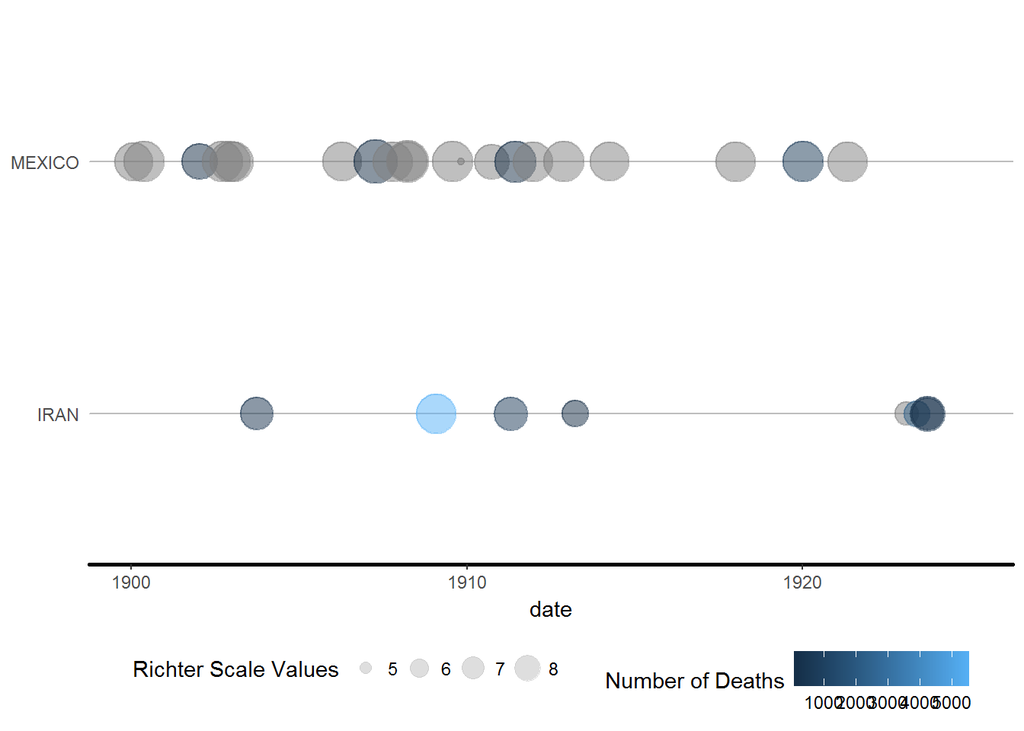

```r
input_data <- noaa.visualise::eq_country_filter(data, countries = c("MEXICO", "IRAN"),
                                            xmin = as.Date("1000-01-01"),
                                            xmax = as.Date("2010-01-01"))

ggplot2::ggplot(input_data, ggplot2::aes (x = date, y = COUNTRY, color = as.numeric(DEATHS), size = as.numeric(EQ_PRIMARY))) + ## continuous scales set as.numeric()

## geom_timeline
noaa.visualise::geom_timeline(ggplot2::aes(xmin = as.Date("1900-01-01"), xmax =  as.Date("1925-01-01"))) +
ggplot2::labs(size = "Richter Scale Values", color = "Number of Deaths" )+

noaa.visualise::theme_timeline()
```

#### geom_timeline_label()

The `geom_timeline()` could be used in conjuction with `geom_timeline_label()`, which would add annotations to each data point in the timeline.

- `label` is the variable in the dataset where it obtains the text annotation.
- `n_max` is the option to subset the dataset to n_max largest (by magnitude) earthquakes.

For example:

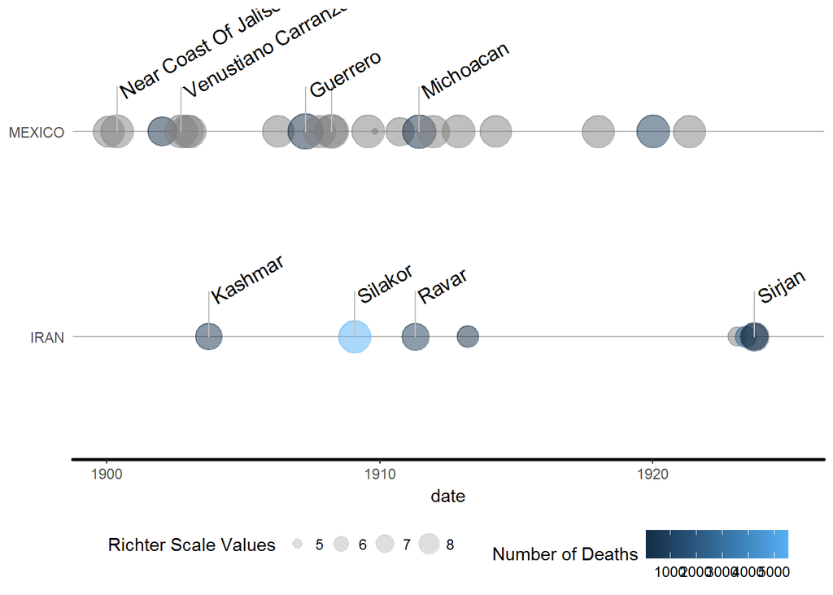

```r
data("raw_data")
data <- noaa.visualise::eq_clean_data(raw_data)
data <- noaa.visualise::eq_location_clean(data) ## to create the text annotation
input_data <- noaa.visualise::eq_country_filter(data, countries = c("MEXICO", "IRAN"),
                                            xmin = as.Date("1000-01-01"),
                                            xmax = as.Date("2010-01-01"))

ggplot2::ggplot(input_data, ggplot2::aes (x = date, y = COUNTRY, color = as.numeric(DEATHS), size = as.numeric(EQ_PRIMARY))) +

## geom_timeline
noaa.visualise::geom_timeline(ggplot2::aes(xmin = as.Date("1900-01-01"), xmax =  as.Date("1925-01-01"))) +
ggplot2::labs(size = "Richter Scale Values", color = "Number of Deaths" )+

## geom_timeline_label
noaa.visualise::geom_timeline_label(ggplot2::aes(label = LOCATION_NAME,
                          xmin = as.Date("1900-01-01"), xmax = as.Date("1925-01-01")),
                          n_max = 5) +

noaa.visualise::theme_timeline()
```

#### stat_timeline() and theme_timeline()

- `stat_timeline()` are set as the default stat for both `geom_timeline()` and `geom_timeline_label()`.
- `theme_timeline()` is the new theme to create the better timeline visualisation.

## Mapping Tools

#### eq_map()

In addition to the visualisation by time, the package provides the tools `eq_map()` to visualise the earthquake data points by their geographical location on the map, by `LONGITUDE` and `LATITUDE`. The radius of the earthquake points are the Magnitude (`EQ_PRIMARY`).

For each point, the user could choose the information for **pop-up annotation** through the argument `annot_col`.

For example, with `annot_col = "date"`:

```r
data("raw_data")
data <- noaa.visualise::eq_clean_data(raw_data)
input_data <- dplyr::filter(data, COUNTRY == "MEXICO" &
                                          lubridate::year(date) >= 2000)
## eq_map
noaa.visualise::eq_map(input_data, annot_col = "date") ## annot_col as "date"
```

[interactive chart not shown]

#### eq_create_label()

To provide more interesting information for the pop-up annotaion, the `eq_create_label()` could be used to create the `popup_text` column in the data frame, which includes the information of **Location**, **Total Deaths**, and **Magnitude** of each earthquakes.

For example,

```r
library(magrittr)
data("raw_data")
data <- noaa.visualise::eq_clean_data(raw_data)
input_data <- dplyr::filter(data, COUNTRY == "MEXICO" &
                                          lubridate::year(date) >= 2000)%>%
  dplyr::mutate(popup_text = noaa.visualise::eq_create_label(.)) ## create popup_text

noaa.visualise::eq_map(input_data, annot_col = "popup_text") ## annot_col set as popup_text
```

[interactive chart not shown]